# MY_EPL_LEAGUE_PRESENTATION slides

## INTRODUCTION

### About Dataset

#### Context

This dataset is a collection of basic but crucial stats of the English Premier League 2020-21 season. The dataset has all the players that played in the EPL and their standard stats such as Goals, Assists, xG, xA, Passes Attempted, Pass Accuracy and more.

### Content

| Attribute | Description |
| --- | --- |
| Position | Each player has a certain position, in which he plays regularly. The position in this dataset are, FW - Forward, MF - Midfield, DF - Defensive, GK - Goalkeeper |
| Starts | The number of times the player was named in the starting 11 by the manager. |
| Mins | The number of minutes played by the player. |
| Goals | The number of Goals scored by the player. |
| Assists | The number of times the player has assisted other player in scoring the goal. |
| Passes_Attempted | The number of passes attempted by the player. |
| PercPassesCompleted | The number of passes that the player accurately passed to his teammate. |
| xG | Expected number of goals from the player in a match. |
| xA | Expected number of assists from the player in a match. |
| Yellow_Cards | The players get a yellow card from the referee for indiscipline, technical fouls, or other minor fouls. |
| Red Card | The players get a red card for accumulating 2 yellow cards in a single game, or for a major foul. |

### TOTAL GOALS SCORED IN THE LEAGUE SEASON

```
986
```

> A total of 986 goals was scored in the league season

### TOTAL PENALTIES CONVERTED

```
102
```

> Out of the total goals scored , penalties accounted for 102 of those goals .

### TOTAL PENALTIES AWARDED

```
125
```

> A total of 125 penalties were awarded in the league season.

### TOTAL NUMBER OF PENALTIES MISSED

```
23
```

> 23 penalties awarded were missed in the league season

### PENALTIES CONVERTED VS PENALTIES MISSED

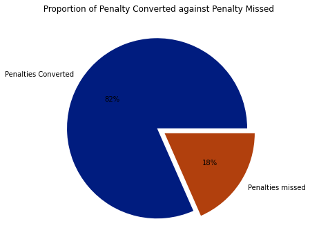

> - Penalty conversion rate stood at 82%, with only 18% of takers missing their spotkick.

### TOP 10 HIGHEST SCORING TEAMS IN THE LEAGUE

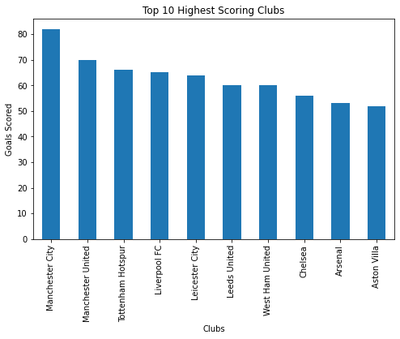

[figure not shown]

> - Manchester city scored the most goals for the season, scoring 82 goals for the season.
> - Manchester united scored the second most goals in the season scoring 70 goals
> - Tottenham hotspur , liverpool and leicester city completed the top 5 scoring teams in the league.

### LEAST SCORING TEAMS IN THE LEAGUE

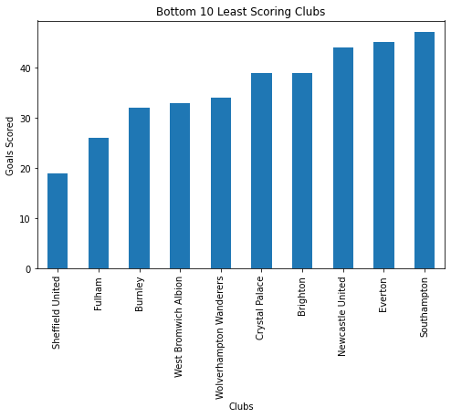

[figure not shown]

> Sheffield united , Fulham and Burnley were the three least scoring sides in the league, with Sheffield united scoring the least number of goals, scoring 19 goals in 38 matches.

### AGE DISTRIBUTION OF PLAYERS IN THE LEAGUE

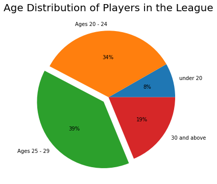

> Players between the ages of 25 to 29 account for the highest age group distribution within the league. with players from 20 to 29 accounting for almost 75% of the total players in the league.

### AVERAGE AGE OF PLAYERS BY FOOTBALL CLUBS

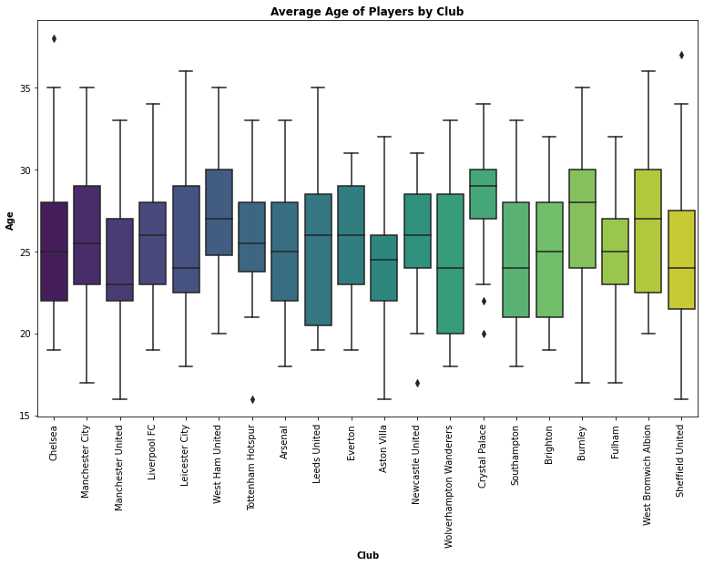

> Visualizing the average ages of players in each club, showed that manchester united had the youngest squad with an average age of 23 whilst crystal palace had the oldest squad with an average age of 28.

### TOP GOAL SCORERS

|  | index | name | club | goals | matches |
| --- | --- | --- | --- | --- | --- |
| 0 | 162 | Harry Kane | Tottenham Hotspur | 23 | 35 |
| 1 | 81 | Mohamed Salah | Liverpool FC | 22 | 37 |
| 2 | 51 | Bruno Fernandes | Manchester United | 18 | 37 |
| 3 | 161 | Son Heung-min | Tottenham Hotspur | 17 | 37 |
| 4 | 214 | Patrick Bamford | Leeds United | 17 | 38 |
| 5 | 237 | Dominic Calvert-Lewin | Everton | 16 | 33 |
| 6 | 110 | Jamie Vardy | Leicester City | 15 | 34 |
| 7 | 267 | Ollie Watkins | Aston Villa | 14 | 37 |
| 8 | 33 | İlkay Gündoğan | Manchester City | 13 | 28 |
| 9 | 191 | Alexandre Lacazette | Arsenal | 13 | 31 |

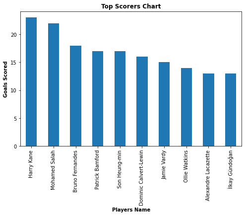

[figure not shown]

> Harry of Tottenham Hotspur scored the most number of goals in the league with a tally of 23 goals in 35 matches, with mohammed salah of salah being short of kane's tally by a single goal, though he played more matches, having played 2 more games more than kane.

### TOP GOAL ASSISTERS

|  | index | name | club | assists | matches |
| --- | --- | --- | --- | --- | --- |
| 0 | 162 | Harry Kane | Tottenham Hotspur | 14 | 35 |
| 1 | 34 | Kevin De Bruyne | Manchester City | 12 | 25 |
| 2 | 51 | Bruno Fernandes | Manchester United | 12 | 37 |
| 3 | 161 | Son Heung-min | Tottenham Hotspur | 10 | 37 |
| 4 | 273 | Jack Grealish | Aston Villa | 10 | 26 |
| 5 | 54 | Marcus Rashford | Manchester United | 9 | 37 |
| 6 | 110 | Jamie Vardy | Leicester City | 9 | 34 |
| 7 | 220 | Raphael Dias Belloli | Leeds United | 9 | 30 |
| 8 | 2 | Timo Werner | Chelsea | 8 | 35 |
| 9 | 136 | Aaron Cresswell | West Ham United | 8 | 36 |

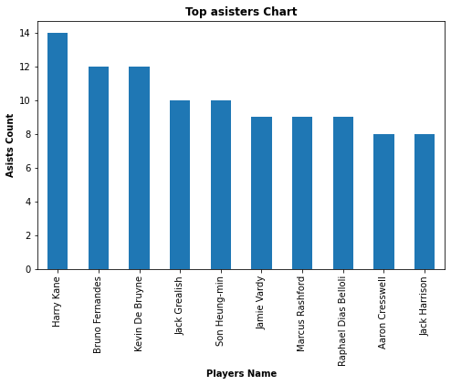

[figure not shown]

> Not only did Harry Kane score the most goals in the league season, he also assisted the most goals with a tally of 14 goals, with kevin De bruyne of Manchester city coming closest with two assists shy of Kane's tally.